# Analysis of of the Adverse Health and Economic Impacts of US Storms

Omar Mohamed

2019 M06 30

## Synopsis

This project involves exploring the U.S. National Oceanic and Atmospheric Administration’s (NOAA) storm database. This database tracks characteristics of major storms and weather events in the United States, including when and where they occur, as well as estimates of any fatalities, injuries, and property damage

The basic goal is to explore the NOAA Storm Database and answer some basic questions about severe weather events. You must use the database to answer the questions below and show the code for your entire analysis.

There is also some documentation of the database available. Here you will find how some of the variables are constructed/defined.

- National Weather Service [Storm Data Documentation](https://d396qusza40orc.cloudfront.net/repdata%2Fpeer2_doc%2Fpd01016005curr.pdf)
- National Climatic Data Center Storm Events [FAQ](https://d396qusza40orc.cloudfront.net/repdata%2Fpeer2_doc%2FNCDC%20Storm%20Events-FAQ%20Page.pdf)

## libraries used

```r
library(dplyr)
```

```r
library(ggplot2)
```

## Loading and Processing the Raw Data

- download Storm Data and save it in **df**
- **Property damage estimates** were entered as actual dollar amounts (the variable **PROPDMG**). But they were rounded to three significant digits, followed by an alphabetical character signifying the magnitude of the number, Alphabetical characters used to signify magnitude include “K” for thousands, “M” for millions, and “B” for billions. So I created a new variable PROPDMGEXP2 and assigned conditionally “K” = 1000, “M” = 1000000, “B” = 1000000000, in other cases 1. These variables are multiplied in the next step.
- show first 2 rows

note : i just commented **download.file(…)** because i download it when i working on it and when run knit make time faster but when you work on it you must uncomment this line and download the data

```r
data_url <- "https://d396qusza40orc.cloudfront.net/repdata%2Fdata%2FStormData.csv.bz2"
if(!file.exists("data")){dir.create("data")}
#download.file(data_url , destfile = "./data/repdata%2Fdata%2FStormData.csv.bz2")
df <- read.csv("C:/Users/omar/Documents/Exploring-NOAA-storm-database/data/repdata%2Fdata%2FStormData.csv.bz2")
df$PROPDMGEXP2 <- 1
df$PROPDMGEXP2[which(df$PROPDMGEXP == "K")] <- 1000
df$PROPDMGEXP2[which(df$PROPDMGEXP == "M" | df$PROPDMGEXP == "m")] <- 1000000
df$PROPDMGEXP2[which(df$PROPDMGEXP == "B")] <- 1000000000
head(df,n=2)
```

```
##   STATE__          BGN_DATE BGN_TIME TIME_ZONE COUNTY COUNTYNAME STATE
## 1       1 4/18/1950 0:00:00     0130       CST     97     MOBILE    AL
## 2       1 4/18/1950 0:00:00     0145       CST      3    BALDWIN    AL
##    EVTYPE BGN_RANGE BGN_AZI BGN_LOCATI END_DATE END_TIME COUNTY_END
## 1 TORNADO         0                                               0
## 2 TORNADO         0                                               0
##   COUNTYENDN END_RANGE END_AZI END_LOCATI LENGTH WIDTH F MAG FATALITIES
## 1         NA         0                        14   100 3   0          0
## 2         NA         0                         2   150 2   0          0
##   INJURIES PROPDMG PROPDMGEXP CROPDMG CROPDMGEXP WFO STATEOFFIC ZONENAMES
## 1       15    25.0          K       0
## 2        0     2.5          K       0
##   LATITUDE LONGITUDE LATITUDE_E LONGITUDE_ REMARKS REFNUM PROPDMGEXP2
## 1     3040      8812       3051       8806              1        1000
## 2     3042      8755          0          0              2        1000
```

Show number of rows and columns

```r
print(dim(df))
```

```
## [1] 902297     38
```

show Columns Names

```r
colnames(df)
```

```
##  [1] "STATE__"     "BGN_DATE"    "BGN_TIME"    "TIME_ZONE"   "COUNTY"
##  [6] "COUNTYNAME"  "STATE"       "EVTYPE"      "BGN_RANGE"   "BGN_AZI"
## [11] "BGN_LOCATI"  "END_DATE"    "END_TIME"    "COUNTY_END"  "COUNTYENDN"
## [16] "END_RANGE"   "END_AZI"     "END_LOCATI"  "LENGTH"      "WIDTH"
## [21] "F"           "MAG"         "FATALITIES"  "INJURIES"    "PROPDMG"
## [26] "PROPDMGEXP"  "CROPDMG"     "CROPDMGEXP"  "WFO"         "STATEOFFIC"
## [31] "ZONENAMES"   "LATITUDE"    "LONGITUDE"   "LATITUDE_E"  "LONGITUDE_"
## [36] "REMARKS"     "REFNUM"      "PROPDMGEXP2"
```

show summary of StormData

```r
str(df)
```

```
## 'data.frame':    902297 obs. of  38 variables:
##  $ STATE__    : num  1 1 1 1 1 1 1 1 1 1 ...
##  $ BGN_DATE   : Factor w/ 16335 levels "1/1/1966 0:00:00",..: 6523 6523 4242 11116 2224 2224 2260 383 3980 3980 ...
##  $ BGN_TIME   : Factor w/ 3608 levels "00:00:00 AM",..: 272 287 2705 1683 2584 3186 242 1683 3186 3186 ...
##  $ TIME_ZONE  : Factor w/ 22 levels "ADT","AKS","AST",..: 7 7 7 7 7 7 7 7 7 7 ...
##  $ COUNTY     : num  97 3 57 89 43 77 9 123 125 57 ...
##  $ COUNTYNAME : Factor w/ 29601 levels "","5NM E OF MACKINAC BRIDGE TO PRESQUE ISLE LT MI",..: 13513 1873 4598 10592 4372 10094 1973 23873 24418 4598 ...
##  $ STATE      : Factor w/ 72 levels "AK","AL","AM",..: 2 2 2 2 2 2 2 2 2 2 ...
##  $ EVTYPE     : Factor w/ 985 levels "   HIGH SURF ADVISORY",..: 834 834 834 834 834 834 834 834 834 834 ...
##  $ BGN_RANGE  : num  0 0 0 0 0 0 0 0 0 0 ...
##  $ BGN_AZI    : Factor w/ 35 levels "","  N"," NW",..: 1 1 1 1 1 1 1 1 1 1 ...
##  $ BGN_LOCATI : Factor w/ 54429 levels "","- 1 N Albion",..: 1 1 1 1 1 1 1 1 1 1 ...
##  $ END_DATE   : Factor w/ 6663 levels "","1/1/1993 0:00:00",..: 1 1 1 1 1 1 1 1 1 1 ...
##  $ END_TIME   : Factor w/ 3647 levels ""," 0900CST",..: 1 1 1 1 1 1 1 1 1 1 ...
##  $ COUNTY_END : num  0 0 0 0 0 0 0 0 0 0 ...
```

[output cut: 24 more lines]

# which types of events are most harmful to population health?

**Fatalities** and **injuries** have the most impact on public health, so I will present what types of severe weather are the most dangerous.

## first working on **fatalities**

1- group the data by the **event** then summarize with the summation of **fatalities**

2- sort by descending order and select first 8 rows

```r
#grouped.data <- df %>% group_by(EVTYPE) %>% summarize(SumFATALITIES = sum(FATALITIES))
grouped.data <- df %>% dplyr::group_by(EVTYPE) %>% dplyr::summarize(SumFATALITIES = sum(FATALITIES))
grouped.data <- dplyr::arrange(grouped.data , desc(SumFATALITIES))
grouped.data <- grouped.data[1:8,]
```

3- plot presents FATALITIES by Event type

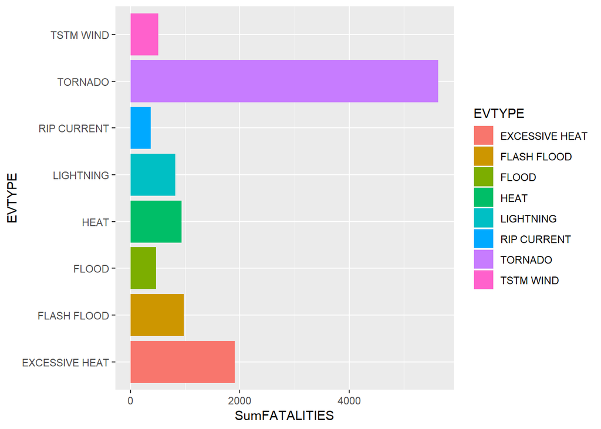

```r
ggplot(grouped.data , aes(x = EVTYPE , y = SumFATALITIES,fill=EVTYPE)) + geom_bar(stat = "identity")+coord_flip()
```

## second working on **injuries**

1- group the data by the **event** then summarize with the summation of **injuries**

2- sort by descending order and select first 8 rows

```r
grouped.data2 <- df %>% dplyr::group_by(EVTYPE) %>% dplyr::summarize(SumInjuries = sum(INJURIES))
grouped.data2 <- dplyr::arrange(grouped.data2 , desc(SumInjuries))
grouped.data2 <- grouped.data2[1:8,]
```

3- plot presents injuries by Event type

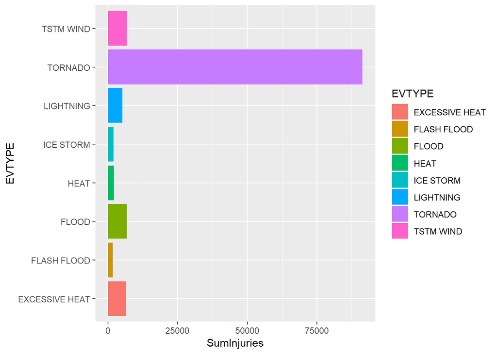

```r
ggplot(grouped.data2 , aes(x = EVTYPE , y = SumInjuries ,fill=EVTYPE)) + geom_bar(stat = "identity")+coord_flip()
```

# Which types of events have the greatest economic consequences?

1- create new variable called **SumPROPDMGEXP** and equal **(PROPDMG * PROPDMGEXP2)**

2- group the data by the **event** then summarize with the summation of **SumPROPDMGEXP**

3- sort by descending order and select first 8 rows

```r
df <- dplyr::mutate(df , SumPROPDMGEXP = PROPDMG * PROPDMGEXP2)
grouped.data3 <- df %>% dplyr::group_by(EVTYPE) %>% dplyr::summarize(property_damage_estimate = sum(SumPROPDMGEXP))

grouped.data3 <- dplyr::arrange(grouped.data3 , desc(property_damage_estimate))
grouped.data3 <- grouped.data3[1:8,]
```

plot shows Property damage estimates by Event type

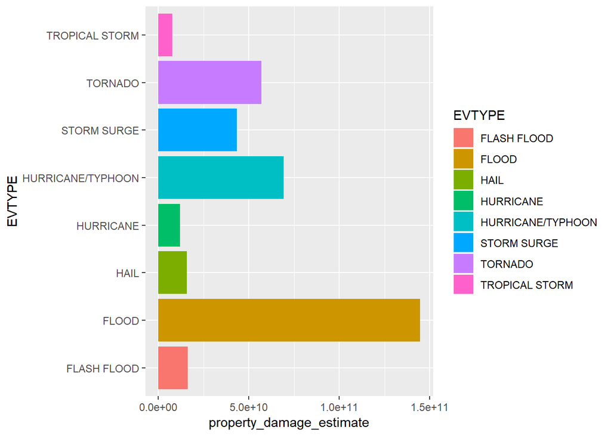

```r
ggplot(grouped.data3 , aes(x = EVTYPE , y=property_damage_estimate)) + geom_bar(stat = "identity" , aes(fill=EVTYPE))+coord_flip()
```

# summary and conclusion

**flood** has the *greatest economic consequences*.

**Tornado** is *the most harmful to population health* because caused the most FATALITIES and injuries.